# TCGA-BRCA TNBC

Sung Rye Park

2024-07-20

### Initial Email 24.07.08

We were wondering if you could take the breast cancer cell lines and categorize them into the different types as above (TNBC, Basal, HER2, Luminal A, Luminal B) and then look at Trop2 expression. I have included what we did in the past using the TCGA for IKKE.

As you know, Ze-Hua found a very interesting clone of TNBC cells that are TROP2 negative (most TNBCs are TROP2 positive). We were hoping to see how TROP2 expression varies among the different breast cancer cell types.

We would then want to further categorize the TROP2 negative lines and as a starter look at STING expression.

### Method

[Paper: Targeting an IKBKE cytokine network impairs triple-negative breast cancer growth](https://pubmed.ncbi.nlm.nih.gov/25365225/)

#### Method Section

**Gene expression profiling.**  
Analyses were performed using TCGA data (2) and applied single-sample gene set enrichment analysis of an IL-1 signature as described previously (26, 52). For details, see the Supplemental Methods.

- 52. Barbie DA, et al. Systematic RNA interference reveals that oncogenic KRAS-driven cancers require TBK1. Nature. 2009;462(7269):108–112.
- 26. Jura J, et al. Identification of interleukin-1 and interleukin-6-responsive genes in human mono- cyte-derived macrophages using microarrays. Biochim Biophys Acta. 2008;1779(6):383–389.
- 2. Koboldt DC, et al. Comprehensive molecular portraits of human breast tumours. Nature. 2012;490(7418):61–70.

**Supplement Method: Gene expression profiling analyses**  
TCGA breast cancer transcriptional profiling data previously analyzed in (1) were downloaded from the TCGA website https://tcga-data.nci.nih.gov/docs/publications/brca_2012/ (file BRCA.exp.547.med.txt, level 3 data freeze from November 2011). Data were processed on Agilent custom 244K whole genome arrays for 522 tumors, 3 metastatic tumors, and 22 tumor-adjacent normal and provided as median centered on 17,184 genes. Genes with a low dynamic range (estimated by standard deviation < 0.5 and max - min expression across samples < 1.5) were filtered out and the expression data were restricted to the 12,459 reliable genes. Clinical information on estrogen receptor (ER) status and progesteron receptor (PR) status were available in the BRCA_Clinical.tar/nationwidechildrens.org_ clinical_patient_public_brca.txt file with several clinical information inconsistencies highlighted in (1). ERBB2 clinical status was assessed as described by integrating immunohistochemistry results with FISH results and copy number calls. Breast cancer intrinsic subtypes were assigned for 514 of the 522 primary tumors based on the PAM50 calls (file BRCA.547.PAM50.SigClust.Subtypes.txt) (1, 2) as Basal (98 samples out of which 82 were triple negative tumors), Her2 (58 samples), Luminal A (231 samples) and Luminal B (127 samples). Amplification status for the chr1q32.1 region harboring IKKε as estimated by GISTIC (3) was available for 498 primary tumors.

### Data source page

[Sample link](https://gdc.cancer.gov/about-data/publications/brca_2012)

**Data Link**

- [BRCA.exp.547.med.txt](https://api.gdc.cancer.gov/data/912fe02c-4f6f-4b42-a445-92dec4d4d09a)
  - Full Expression Data set consisting of 522 primary tumors, 3 metastatic tumors, and 22 tumor-adjacent normal samples.
  - Data was median centered by genes.
- [BRCA.547.PAM50.SigClust.Subtypes.txt](https://api.gdc.cancer.gov/data/a2a299a9-6cad-4811-a74c-0bdfa61cbab2)
  - PAM50 and SigClust Subtype Assignments

### Subtype Data

PAM50 (type) in the dataset (Prediction Analysis of Microarray 50 (PAM50))

#### PAM50 sample numbers

|  | PAM50 | Number of Samples |
| --- | --- | --- |
| 1 | Basal | 98 |
| 2 | Her2 | 58 |
| 3 | LumA | 232 |
| 4 | LumB | 129 |
| 5 | Normal | 30 |

### TROP2 Expression

#### TACSTD2 Expression (boxplot)

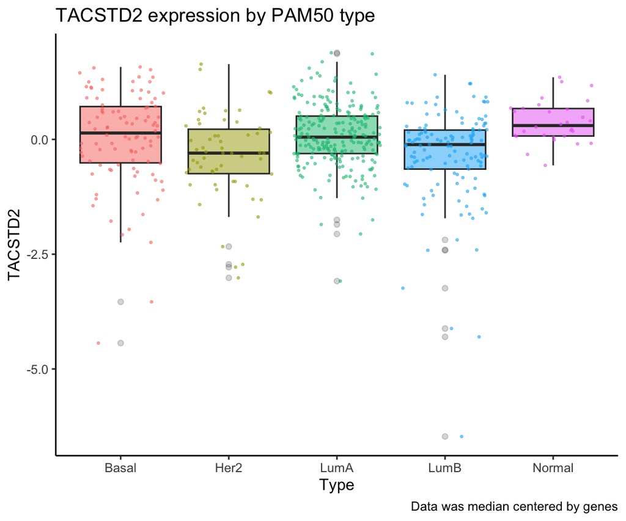

#### TACSTD2 Expression (boxplot) with t-test

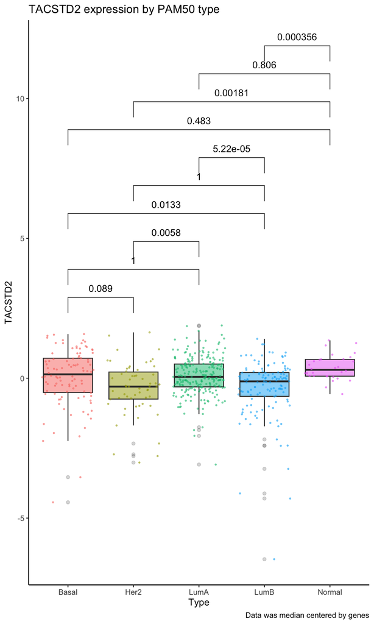

#### TACSTD2 Expression by PAM50 (density)

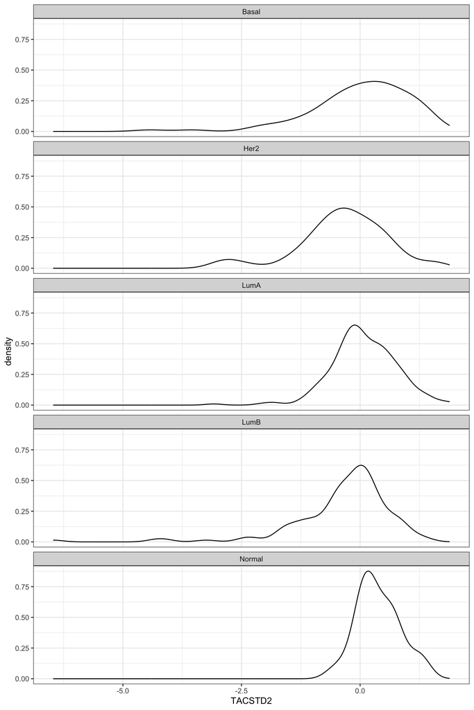

### PAM50 genes expression in the dataset

#### PAM50 Genes

[PAM50 genes](https://www.ncbi.nlm.nih.gov/pmc/articles/PMC2667820/)

[output not shown]

#### Heatmap

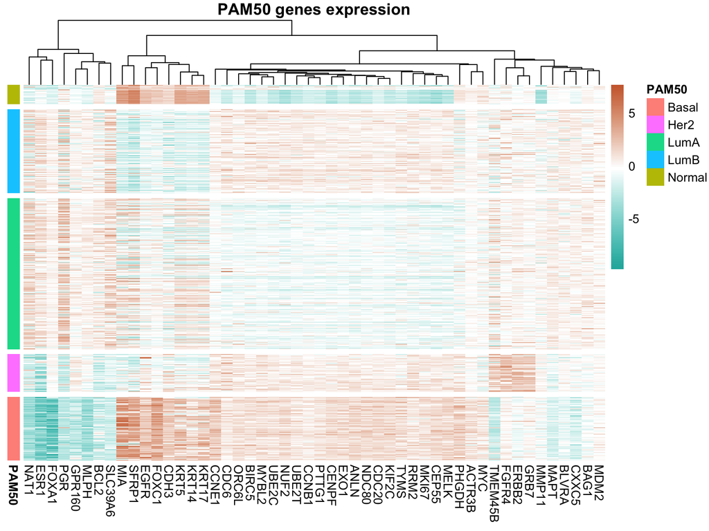

#### Heatmap (transposed and scaled)

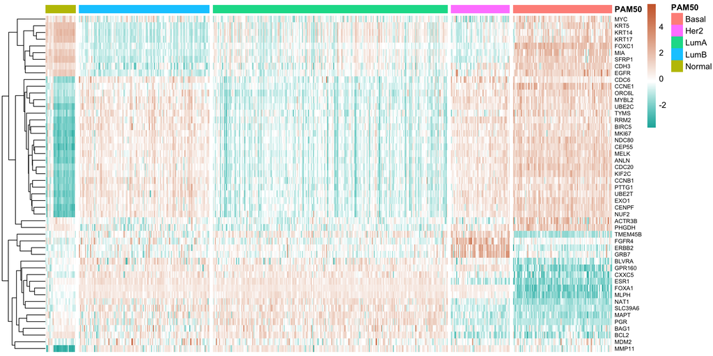